# Predicting Weight-Lifting Technique from Wearable Sensors

Practical Machine Learning course project

Sanidhya Singhal

September 20, 2026

## Executive summary

This analysis predicts how participants performed a barbell lift from accelerometers placed on the belt, forearm, arm, and dumbbell. The target, `classe`, has five levels. Class A represents the correct movement; classes B through E represent four common mistakes.

The source contains 19,622 labeled observations and 20 quiz cases. After identifiers, names, timestamps, window fields, sparse measurements, and a CSV row-number field were removed, 52 complete sensor predictors remained. A random forest was selected because the measurements interact nonlinearly and several orientation, acceleration, gyroscope, and magnetometer signals are correlated.

The random forest achieved **99.61% accuracy** on a 4,906-row validation set that was not used for training or tuning. The corresponding estimated out-of-sample error is **0.39%**. A separate five-fold ensemble check averaged **99.68% accuracy** (standard deviation 0.10 percentage points). The final model was fitted to all labeled rows and used to predict the 20 quiz cases.

## Data preparation

The training data contain 160 columns. Many summary fields are populated only for a small subset of rows. I used a transparent preprocessing rule: retain numeric sensor variables that are complete in both the training and quiz data. I then excluded the following metadata before any split or resampling:

- CSV row identifier
- participant name
- raw and formatted timestamps
- window indicators and window number
- outcome and quiz identifier

These fields describe the collection session rather than the physical movement. Including the row identifier, in particular, produces unrealistically perfect validation results and unstable quiz predictions. Removing it is therefore a leakage control, not merely a convenience.

| Class | Observations |
| --- | --- |
| A | 5,580 |
| B | 3,797 |
| C | 3,422 |
| D | 3,216 |
| E | 3,607 |

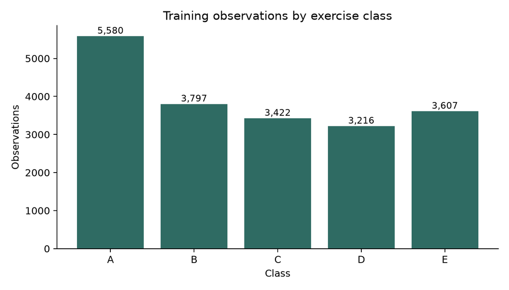

Class counts in the labeled training set

All five classes have thousands of examples, so no class weighting or synthetic balancing was necessary. A stratified split assigned 75% of the data (14,716 rows) to model building and 25% (4,906 rows) to final validation while preserving these proportions.

The reproducible R Markdown source implements the preparation rule directly:

```r
metadata <- c("X", "user_name", "raw_timestamp_part_1",
              "raw_timestamp_part_2", "cvtd_timestamp",
              "new_window", "num_window", "classe", "problem_id")
candidate_names <- setdiff(names(training), metadata)
numeric_names <- candidate_names[
  vapply(training[candidate_names], is.numeric, logical(1))
]
complete_train <- vapply(training[numeric_names],
                         function(x) all(!is.na(x)), logical(1))
complete_test <- vapply(testing[numeric_names],
                        function(x) all(!is.na(x)), logical(1))
predictor_names <- numeric_names[complete_train & complete_test]
```

## Model building and cross-validation

A single decision tree served as a baseline. It is easy to interpret but sensitive to small changes in the data. Random forests reduce this variance by averaging many trees, with a random subset of predictors considered at each split. That structure suits the nonlinear boundaries in multi-device motion signals without requiring feature scaling.

Within the 75% build sample, five stratified folds were used to choose `mtry`, the number of predictors considered at each tree split. Candidate values were 4, 7, and 10. Each candidate was scored on rows omitted from the corresponding fold. The validation set was not used in this choice.

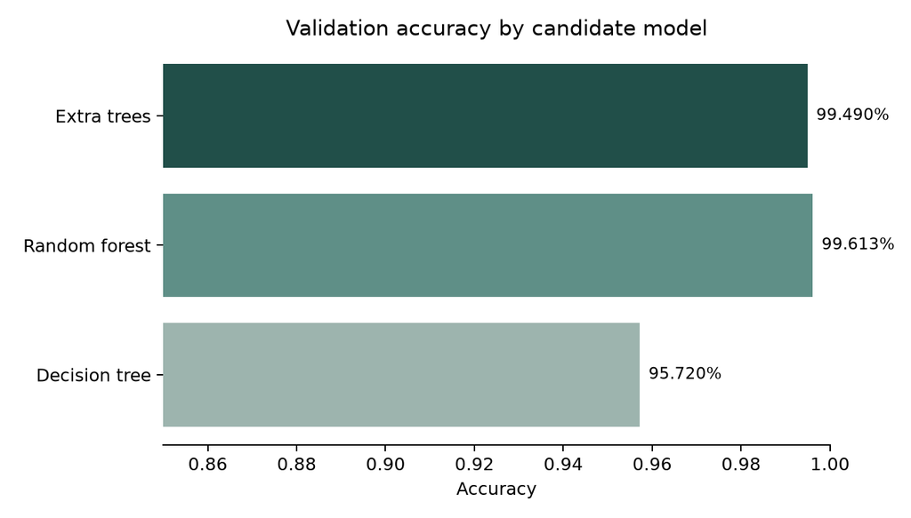

Validation accuracy for the candidate models

| Candidate | Validation accuracy |
| --- | --- |
| Decision tree | 95.72% |
| Random forest | 99.61% |
| Extra-trees robustness check | 99.49% |

The ensembles clearly outperform the single tree. The random forest was retained because it had the highest accuracy on the untouched validation sample. The extra-trees model was used as an independent robustness check across five folds; its fold accuracies ranged from 99.57% to 99.82%, with a mean of 99.68%.

The core R training call is:

```r
control <- trainControl(method = "cv", number = 5,
                        savePredictions = "final")
rf_fit <- train(classe ~ ., data = build, method = "rf",
                trControl = control, metric = "Accuracy",
                tuneGrid = data.frame(mtry = c(4, 7, 10)),
                ntree = 500, importance = TRUE)
```

## Out-of-sample performance

The selected model correctly classified 4,887 of 4,906 held-out rows. Accuracy was 99.61%, so the estimated out-of-sample error is 0.39% for observations drawn in the same way as this data set.

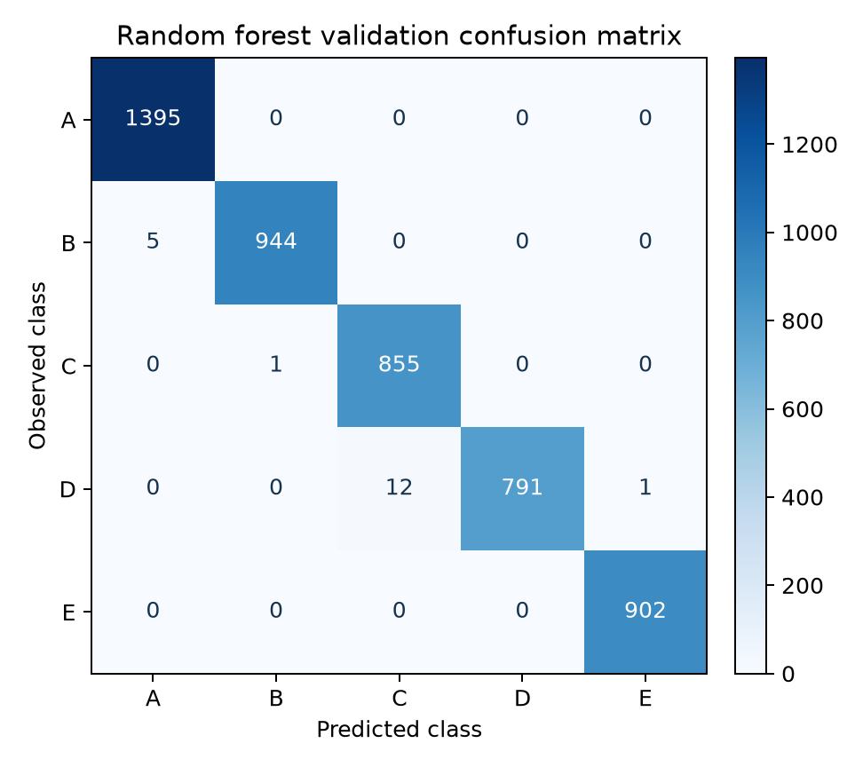

Confusion matrix on the untouched validation set

| Observed Predicted | A | B | C | D | E |
| --- | --- | --- | --- | --- | --- |
| A | 1,395 | 0 | 0 | 0 | 0 |
| B | 5 | 944 | 0 | 0 | 0 |
| C | 0 | 1 | 855 | 0 | 0 |
| D | 0 | 0 | 12 | 791 | 1 |
| E | 0 | 0 | 0 | 0 | 902 |

The model classified every held-out A and E observation correctly. Most of the 19 errors involved D movements classified as C. Errors are small relative to every class total, so there is no evidence that the overall score hides a poorly served class.

This estimate has an important limitation. The random split can place records from the same participant in both the build and validation sets. The reported error therefore measures performance on new records from the course data-generating process, not necessarily on entirely new people, sensor placements, or devices. Participant-grouped validation would answer that harder deployment question but would not match the standard course evaluation setup.

## Important measurements

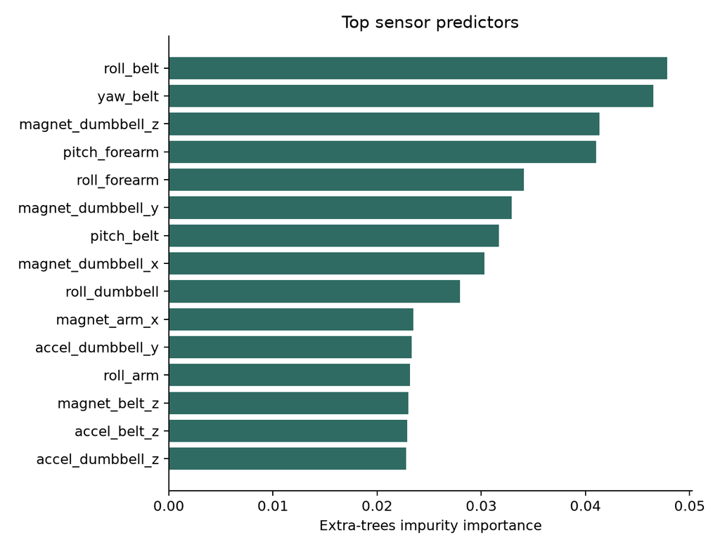

Fifteen most important sensor predictors

Belt roll and yaw, forearm pitch and roll, and dumbbell magnetometer measurements are among the strongest predictors. This is physically plausible because incorrect lifts change both limb orientation and the path of the weight. The importance scores are descriptive rather than causal. Correlated sensors can divide importance between themselves, and impurity-based measures can favor variables with more possible split points.

## Final predictions

After model selection, the random forest was refitted on all 19,622 labeled rows and used to score the 20 quiz cases.

| Problem | Prediction | Problem | Prediction |
| --- | --- | --- | --- |
| 1 | B | 11 | B |
| 2 | A | 12 | C |
| 3 | B | 13 | B |
| 4 | A | 14 | A |
| 5 | A | 15 | E |
| 6 | E | 16 | E |
| 7 | D | 17 | A |
| 8 | B | 18 | B |
| 9 | A | 19 | B |
| 10 | A | 20 | B |

The same values are provided in `quiz_predictions.csv` for direct use.

## Reproducibility

The project includes the R Markdown source, a fixed random seed, explicit missing-value codes, a recorded feature-selection rule, stratified cross-validation, and relative paths. If the source CSV files are absent, the R Markdown downloads them from the public course URLs. Open the project folder in RStudio and knit `practical_machine_learning.Rmd`. The required packages are `caret`, `randomForest`, and `rmarkdown`.

Data sources: [Practical Machine Learning training data](https://d396qusza40orc.cloudfront.net/predmachlearn/pml-training.csv), [quiz data](https://d396qusza40orc.cloudfront.net/predmachlearn/pml-testing.csv), and the [Weight Lifting Exercise Dataset](http://groupware.les.inf.puc-rio.br/har).